# Numerical Methods for PDEs (Spring 2017), Lab 7

Richard Southwell, Gustav Delius

# Non-homogeneous equation and boundary conditions

Let’s load the 3D graphics library because we will use it later.

```r
library(plot3Drgl)
```

We now allow a general inhomogeneous term $f(x,t)$, depending on both space and time, on the right-hand side of the heat equation
$$u_{t}(x,t) - K u_{xx}(x,t) = f(x,t), \quad 0<x<L, \quad 0<t<T,$$
subject to the time-dependent boundary conditions
$$u(0, t) = a(t), ~~~u(L, t) = b(t),$$
and initial condition $u(x,t) = u_0(x)$.

## Forward difference method

Here is the `forwardDifference()` function from lab 4:

```r
forwardDifference <- function(f=function(x) 0,
                              u0=function(x) 2*sin(2*pi*x),
                              K=1, L=1, N=30, T=0.1, M=200) {
    # set up space grid
    h <- L/N
    x <- h*(1:(N-1))

    # set up time grid
    tau <- T/M
    t <- tau*(0:M)

    # set up vectors with initial condition and inhomogenous term
    w <- u0(x)
    F <- f(x)

    # Set up evolution matrix
    gamma <- K*tau/(h^2)
    A <- diag(1-2*gamma, N-1)
    for (k in 1:(N-2)) {
        A[k,k+1] <- gamma
        A[k+1,k] <- gamma
    }

    Temperature <- matrix(0, N-1, M+1)  # Matrix to hold the solution
    Temperature[ , 1] <- w  # Initial value
    # Loop over time steps
    for (j in 1:M) {
        w <- A %*% w + tau * F
        w[1] <- w[1] + gamma * a(t[j])
        w[N-1] <- w[N-1] + gamma * b(t[j])
        Temperature[ , j+1] <- w
    }

    # Return a list consisting of time grid, x grid and solution
    return(list(x=x, t=t, w=Temperature))
}
```

1. The parameter `f` now must be a function of two arguments and the evaluation of the vector `F` must be done inside the loop over time steps so that `f` can be evaluated at the correct time.
2. Now that also the boundary values are interesting, we will extend the `w` array to hold all values $w_{k,j}$ for $k=0,\dots,N$ and $j=0,\dots,M$, where previously we had not included the boundary points $w_{0,j}$ and $w_{N,j}$. Because matrix indices in R start at 1 and not at zero, we have to use shifted indices so that $w_{k,j}=$`w[k+1,j+1]`. We must also remember to set $w_{0,j}=a(t_j)$ and $w_{N,j}=b(t_j)$ at each time step.

This gives the following code:

```r
forwardDifference <- function(f=function(x, t) 0,
                              u0=function(x) 2*sin(2*pi*x),
                              a= function(t) 0, b=function(t) 0,
                              K=1, L=1, N=30, T=0.1, M=200) {
    # set up space grid
    h <- L/N
    x <- h*(0:N)

    # set up time grid
    tau <- T/M
    t <- tau*(0:M)

    # set up vectors with initial condition and inhomogenous term
    w <- u0(x)

    # Set up evolution matrix
    gamma <- K*tau/(h^2)
    A <- diag(1-2*gamma, N+1)
    for (k in 1:N) {
        A[k,k+1] <- gamma
        A[k+1,k] <- gamma
    }

    Temperature <- matrix(0, N+1, M+1)  # Matrix to hold the solution
    Temperature[ , 1] <- w  # Initial value
    # Loop over time steps
    for (j in 1:M) {
        F <- f(x, t[j])
        w <- A %*% w + tau * F
        w[1] <- a(t[j+1])
        w[N+1] <- b(t[j+1])
        Temperature[ , j+1] <- w
    }

    # Return a list consisting of time grid, x grid and solution
    return(list(x=x, t=t, w=Temperature))
}
```

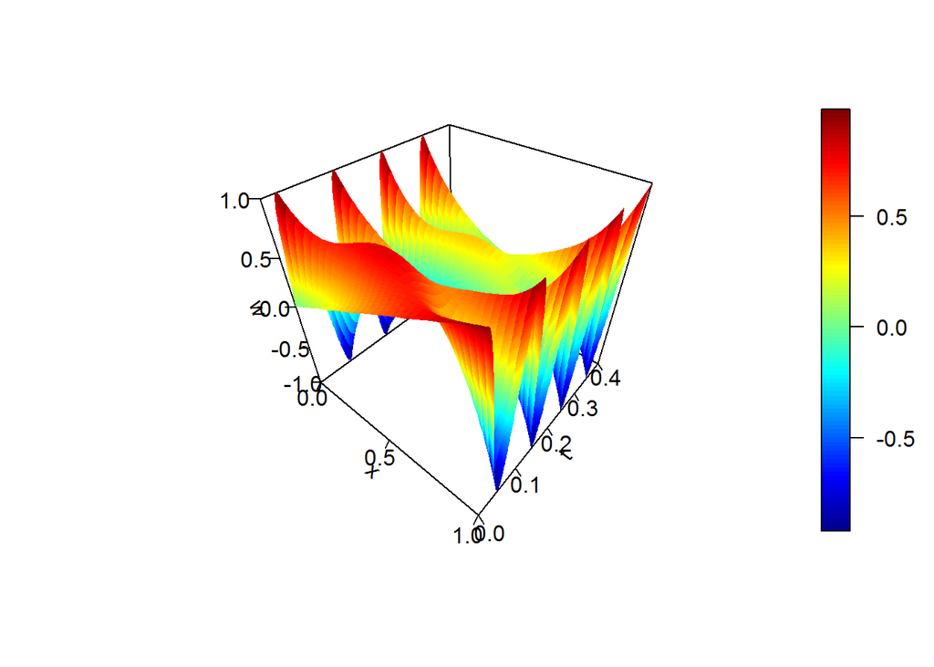

```r
sol <- forwardDifference(u0=function(x) x,
                         f=function(x,t) 10*sin(10*pi*t)*exp(-10*(x-0.5)^2),
                         a=function(t) sin(20*pi*t), b=function(t) cos(20*pi*t),
                         K=1, L=1, T=0.4, N=30, M=720)
persp3D(sol$x, sol$t, sol$w,
        xlab="x", ylab="t", zlab="w",
        ticktype="detailed", nticks=4)
```

```r
plotrgl(smooth=TRUE, lighting = TRUE)
```

## Exercise: Backward difference method

Now please modify our old code for the backward difference method so that it too can deal with the problem at the top of this worksheet with its time-dependent inhomogeneities in both the PDE and the boundary conditions.

Here is the `backwardDifference()` function from my solutions for lab 5:

```r
backwardDifference <- function(u0=function(x) 2*sin(2*pi*x),
                              K=1, L=1, N=30, T=0.1, M=30) {
    # set up space grid
    h <- L/N
    x <- h*(1:(N-1))

    # set up time grid
    tau <- T/M
    t <- tau*(0:M)

    # set up vectors with initial condition
    w <- u0(x)

    gamma <- K*tau/(h^2)

    Temperature <- matrix(0, N-1, M+1)  # Matrix to hold the solution
    Temperature[ , 1] <- w  # Initial value
    # Loop over time steps
    for (j in 1:M) {
        w <- doublesweep(rep(gamma, N-1), rep(gamma, N-1),
                         rep(1 + 2* gamma, N-1), -w, 0, 0)
        Temperature[ , j+1] <- w
    }

    # Return a list consisting of time grid, x grid and solution
    return(list(x=x, t=t, w=Temperature))
}
```

It uses our implementation of the doublesweep method:

```r
doublesweep <- function(A, B, C, F, a, b) {
    # Solves the equation
    # A[i]*v[i-1] - C[i]*v[i] + B[i]*v[i+1] = F[i]
    # for v[i], i = 1,...,N-1, with boundary conditions
    # v[0]=a and v[N]=b

    # Check the lengths of the vectors
    N <- length(C) + 1
    if ((length(B) != N-1) || (length(A) != N-1) || (length(F) != N-1)) {
        stop("The lengths of the vector arguments need to be equal")
    }

    alpha <- rep(0, N)
    beta <- rep(0, N)
    beta[1] <- a

    #sweep up to get alphas and betas
    for (i in 1:(N-1)) {
        alpha[i+1] <- B[i] / (C[i]-alpha[i]*A[i])
        beta[i+1] <- (beta[i]*A[i] - F[i]) / (C[i] - alpha[i]*A[i])
    }

    v <- rep(0, N-1 )
    v[N-1] <- alpha[N]*b + beta[N]

    #sweep down to find v's
    for (i in (N-1):2) {
        v[i-1] <- alpha[i]*v[i] + beta[i]
    }

    return(v)
}
```